# Оценка эффекта воздействия мер адресной государственной поддержки на финансовую состоятельность юридических лиц - субъектов МСП

Дизайн исследования. Исходные данные.

Сергей Старков

Магистратура, программа ‘Экономический анализ’

2026-03-18

## Источники, методология сбора, подготовки и анализа данных.

### Анализ данных. Экономическая модель.

Причинно - следственные связи оказываемых мер поддержки и финансового состояния фирм. DAG.

[output not shown]

### Анализ данных. Инструменты Causal Inference.

1. Оценка ATT с помощью DiD с динамическим лечением (разнопериодным) Staggered DiD (Callaway и Sant’Anna 2021).
2. Оценка ATE (CATE), анализ интенсивности воздействия с помощью Dynamic (Continuous Treatment) DoubleML (Bodory, Huber, и Lafférs 2022).
3. CATE, исследование факторов гетерогенности и распределения эффектов с помощью Causal Forest (Athey, Tibshirani, и Wager 2019; Zheng и Yin 2023).

### Анализ данных. Проверка робастности:

- плацебо - тесты;
- альтернативные переменные воздействия (ROA, коэффициент текущей ликвидности, Z - счет Альтмана);
- синтетические контрфакты SCM-ITE (Abadie 2021; Dube и Misra 2023).

## Источники данных. Российская база бухгалтерской отчетности (РББО).

Датасет содержит информацию из бухгалтерской отчетности всех российских фирм за 2011–2024 гг.

- **Источник:** Лаборатория исследования судебной практики ИПП ЕУСПб
- **Публикация:** Bondarkov, Ledenev, Skougarevskiy (Bondarkov, Ledenev, и Skougarevskiy 2025).
- 4 - 4.4 млн. фирм/год;
- уникальные идентификаторы фирм ИНН, ОГРН;
- полные описания фирм (название, коды учета, отрасль, дата создания и ликвидации, геоданные и т.д.);
- все строки полной бухгалтерской отчетности.

[figure not shown]

### Выборка данных из РББО

Записи(фирмы):

- обязаны предоставлять ежегодную бухгалтерскую отчетность;
- нефинансовые организации;
- однозначно идентифицируются;
- пересекаются со временем существования реестра МСП (2017:2024).

Признаки(переменные):

- ИНН;
- основной ОКВЭД;
- регион;
- биография фирмы;
- данные бухгалтерского баланса и отчета о финансовых результатах.

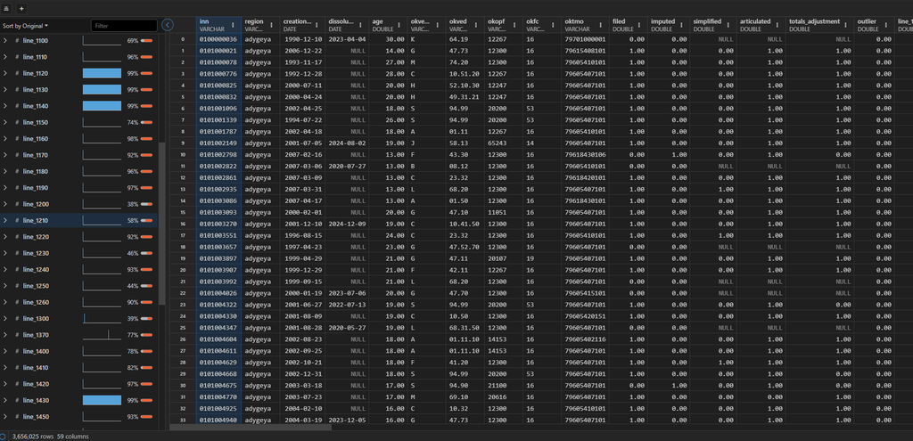

## Единый реестр МСП

(Федеральная налоговая служба 2026a)

- данные ретроспективные, c 2016 года;
- месячные;
- существуют только в виде сжатых архивов .xml на сайте ФНС.

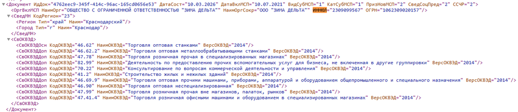

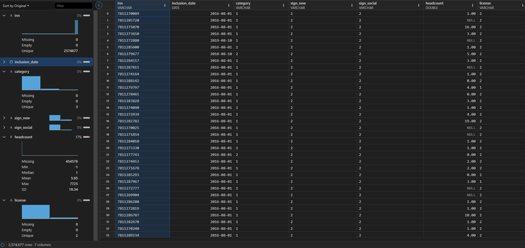

## Реестр субъектов МСП - получателей поддержки

(Федеральная налоговая служба 2026b)

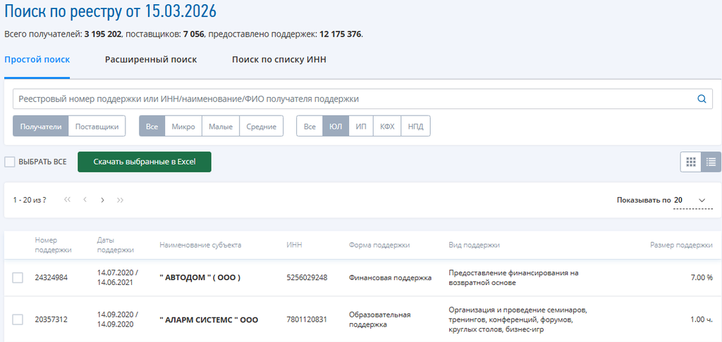

- реестр ведется и публикуется с 2021 года;
- cодержит данные о видах, объемах, сроках, поставщиках поддержки юридических лиц, ИП и самозанятых;
- месячные данные.

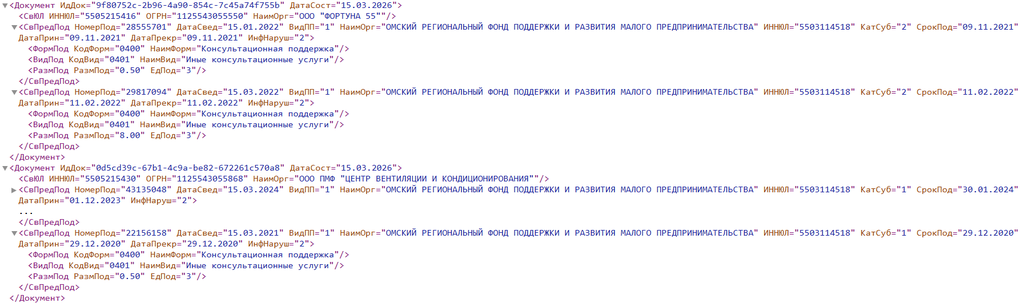

## Переменные

#### Зависимая переменная (Y)

1. Отдельные финансовые показатели: коэффициент текущей ликвидности, коэффициент автономии, ROA, оборачиваемость активов, динамика выручки (прибыли).
2. Интегральные оценки финансового состояния фирм: Z - счет Альтмана, балльные оценки.
3. Интегральный индекс финансовой устойчивости (FSI): агрегирование фактической информации по отдельным финансовым показателям с помощью метода главных компонент (PCA).

#### Переменные воздействия (Treatment):

1. Бинарные индикаторы по видам поддержки.
2. Непрерывные показатели объема поддержки.

#### Ковариаты:

1. Характеристики фирмы: возраст, местоположение, ССЧР, отрасль (ОКВЭД), наличие специального статуса, длительность нахождения в МСП, последовательность и полнота бухгалтерской отчетности.
2. Экзогенные факторы: отраслевые индексы деловой активности.

## Список источников

Abadie, Alberto. 2021. «Using synthetic controls: Feasibility, data requirements, and methodological aspects». *Journal of Economic Literature* 59 (2): 391–425.

Athey, Susan, Julie Tibshirani, и Stefan Wager. 2019. «Generalized random forests». *The Annals of Statistics* 47 (2): 1148–78.

Bodory, Hugo, Martin Huber, и Lukáš Lafférs. 2022. «Evaluating (weighted) dynamic treatment effects by double machine learning». *The Econometrics Journal* 25 (3): 628–48.

Bondarkov, Sergey, Victor Ledenev, и Dmitriy Skougarevskiy. 2025. «Russian Financial Statements Database». *Scientific Data* 12. https://doi.org/10.1038/s41597-025-05150-1.

Callaway, Brantly, и Pedro HC Sant’Anna. 2021. «Difference-in-differences with multiple time periods». *Journal of Econometrics* 225 (2): 200–230.

Dube, Jean-Pierre, и Sanjog Misra. 2023. «Synthetic control methods for individual treatment effects». *Marketing Science* 42 (1): 1–21.

Zheng, Li, и Wei Yin. 2023. «Estimating and evaluating treatment effect heterogeneity: A causal forests approach». *Research & Politics* 10 (1): 20531680231154563.

Федеральная налоговая служба. 2026a. «Открытые данные: Единый реестр субъектов малого и среднего предпринимательства». https://www.nalog.gov.ru/opendata/7707329152-rsmp/.

———. 2026b. «Открытые данные: Единый реестр субъектов малого и среднего предпринимательства — получателей поддержки». https://www.nalog.gov.ru/opendata/7707329152-rsmppp/.